# Description and usage of Spectra objects

24 October 2023

**Package**: *Spectra*  
**Authors**: RforMassSpectrometry Package Maintainer [cre], Laurent Gatto [aut] (https://orcid.org/0000-0002-1520-2268), Johannes Rainer [aut] (https://orcid.org/0000-0002-6977-7147), Sebastian Gibb [aut] (https://orcid.org/0000-0001-7406-4443), Jan Stanstrup [ctb] (https://orcid.org/0000-0003-0541-7369), Nir Shahaf [ctb]  
**Last modified:** 2023-10-24 14:38:15.825743  
**Compiled**: Tue Oct 24 23:23:21 2023

# 1 Introduction

The *Spectra* package provides a scalable and flexible infrastructure to represent, retrieve and handle mass spectrometry (MS) data. The `Spectra` object provides the user with a single standardized interface to access and manipulate MS data while supporting, through the concept of exchangeable *backends*, a large variety of different ways to store and retrieve mass spectrometry data. Such backends range from mzML/mzXML/CDF files, simple flat files, or database systems.

This vignette provides general examples and descriptions for the *Spectra* package. Additional information and tutorials are available, such as [SpectraTutorials](https://jorainer.github.io/SpectraTutorials/), MetaboAnnotationTutorials, or also in (Rainer et al. 2022).

# 2 Installation

The package can be installed with the *BiocManager* package. To install *BiocManager* use `install.packages("BiocManager")` and, after that, `BiocManager::install("Spectra")` to install *Spectra*.

# 3 General usage

Mass spectrometry data in `Spectra` objects can be thought of as a list of individual spectra, with each spectrum having a set of variables associated with it. Besides *core* spectra variables (such as MS level or retention time) an arbitrary number of optional variables can be assigned to a spectrum. The core spectra variables all have their own accessor method and it is guaranteed that a value is returned by it (or `NA` if the information is not available). The core variables and their data type are (alphabetically ordered):

- *acquisitionNum* `integer(1)`: the index of acquisition of a spectrum during a MS run.
- *centroided* `logical(1)`: whether the spectrum is in profile or centroid mode.
- *collisionEnergy* `numeric(1)`: collision energy used to create an MSn spectrum.
- *dataOrigin* `character(1)`: the *origin* of the spectrum’s data, e.g. the mzML file from which it was read.
- *dataStorage* `character(1)`: the (current) storage location of the spectrum data. This value depends on the backend used to handle and provide the data. For an *in-memory* backend like the `MsBackendDataFrame` this will be `"<memory>"`, for an on-disk backend such as the `MsBackendHdf5Peaks` it will be the name of the HDF5 file where the spectrum’s peak data is stored.
- *intensity* `numeric`: intensity values for the spectrum’s peaks.
- *isolationWindowLowerMz* `numeric(1)`: lower m/z for the isolation window in which the (MSn) spectrum was measured.
- *isolationWindowTargetMz* `numeric(1)`: the target m/z for the isolation window in which the (MSn) spectrum was measured.
- *isolationWindowUpperMz* `numeric(1)`: upper m/z for the isolation window in which the (MSn) spectrum was measured.
- *msLevel* `integer(1)`: the MS level of the spectrum.
- *mz* `numeric`: the m/z values for the spectrum’s peaks.
- *polarity* `integer(1)`: the polarity of the spectrum (`0` and `1` representing negative and positive polarity, respectively).
- *precScanNum* `integer(1)`: the scan (acquisition) number of the precursor for an MSn spectrum.
- *precursorCharge* `integer(1)`: the charge of the precursor of an MSn spectrum.
- *precursorIntensity* `numeric(1)`: the intensity of the precursor of an MSn spectrum.
- *precursorMz* `numeric(1)`: the m/z of the precursor of an MSn spectrum.
- *rtime* `numeric(1)`: the retention time of a spectrum.
- *scanIndex* `integer(1)`: the index of a spectrum within a (raw) file.
- *smoothed* `logical(1)`: whether the spectrum was smoothed.

For details on the individual variables and their getter/setter function see the help for `Spectra` (`?Spectra`). Also note that these variables are suggested, but not required to characterize a spectrum. Also, some only make sense for MSn, but not for MS1 spectra.

## 3.1 Creating `Spectra` objects

The simplest way to create a `Spectra` object is by defining a `DataFrame` with the corresponding spectra data (using the corresponding spectra variable names as column names) and passing that to the `Spectra` constructor function. Below we create such an object for a set of 3 spectra providing their MS level, olarity but also additional annotations such as their ID in [HMDB](http://hmdb.ca) (human metabolome database) and their name. The m/z and intensity values for each spectrum have to be provided as a `list` of `numeric` values.

```r
library(Spectra)

spd <- DataFrame(
    msLevel = c(2L, 2L, 2L),
    polarity = c(1L, 1L, 1L),
    id = c("HMDB0000001", "HMDB0000001", "HMDB0001847"),
    name = c("1-Methylhistidine", "1-Methylhistidine", "Caffeine"))

## Assign m/z and intensity values.
spd$mz <- list(
    c(109.2, 124.2, 124.5, 170.16, 170.52),
    c(83.1, 96.12, 97.14, 109.14, 124.08, 125.1, 170.16),
    c(56.0494, 69.0447, 83.0603, 109.0395, 110.0712,
      111.0551, 123.0429, 138.0662, 195.0876))
spd$intensity <- list(
    c(3.407, 47.494, 3.094, 100.0, 13.240),
    c(6.685, 4.381, 3.022, 16.708, 100.0, 4.565, 40.643),
    c(0.459, 2.585, 2.446, 0.508, 8.968, 0.524, 0.974, 100.0, 40.994))

sps <- Spectra(spd)
sps
```

```
## MSn data (Spectra) with 3 spectra in a MsBackendMemory backend:
##     msLevel     rtime scanIndex
##   <integer> <numeric> <integer>
## 1         2        NA        NA
## 2         2        NA        NA
## 3         2        NA        NA
##  ... 18 more variables/columns.
```

Alternatively, it is possible to import spectra data from mass spectrometry raw files in mzML/mzXML or CDF format. Below we create a `Spectra` object from two mzML files and define to use a `MsBackendMzR` backend to *store* the data (note that this requires the *mzR* package to be installed). This backend, specifically designed for raw MS data, keeps only a subset of spectra variables in memory while reading the m/z and intensity values from the original data files only on demand. See section Backends for more details on backends and their properties.

```r
fls <- dir(system.file("sciex", package = "msdata"), full.names = TRUE)
sps_sciex <- Spectra(fls, source = MsBackendMzR())
sps_sciex
```

```
## MSn data (Spectra) with 1862 spectra in a MsBackendMzR backend:
##        msLevel     rtime scanIndex
##      <integer> <numeric> <integer>
## 1            1     0.280         1
## 2            1     0.559         2
## 3            1     0.838         3
## 4            1     1.117         4
## 5            1     1.396         5
## ...        ...       ...       ...
## 1858         1   258.636       927
## 1859         1   258.915       928
## 1860         1   259.194       929
## 1861         1   259.473       930
## 1862         1   259.752       931
##  ... 33 more variables/columns.
##
## file(s):
## 20171016_POOL_POS_1_105-134.mzML
## 20171016_POOL_POS_3_105-134.mzML
```

The `Spectra` object `sps_sciex` allows now to access spectra data from 1862 MS1 spectra and uses `MsBackendMzR` as backend (the `Spectra` object `sps` created in the previous code block uses the default `MsBackendMemory`).

## 3.2 Accessing spectrum data

As detailed above `Spectra` objects can contain an arbitrary number of properties of a spectrum (so called *spectra variables*). The available variables can be listed with the `spectraVariables` method:

```r
spectraVariables(sps)
```

```
##  [1] "msLevel"                 "rtime"
##  [3] "acquisitionNum"          "scanIndex"
##  [5] "dataStorage"             "dataOrigin"
##  [7] "centroided"              "smoothed"
##  [9] "polarity"                "precScanNum"
## [11] "precursorMz"             "precursorIntensity"
## [13] "precursorCharge"         "collisionEnergy"
## [15] "isolationWindowLowerMz"  "isolationWindowTargetMz"
## [17] "isolationWindowUpperMz"  "id"
## [19] "name"
```

```r
spectraVariables(sps_sciex)
```

```
##  [1] "msLevel"                  "rtime"
##  [3] "acquisitionNum"           "scanIndex"
##  [5] "dataStorage"              "dataOrigin"
##  [7] "centroided"               "smoothed"
##  [9] "polarity"                 "precScanNum"
## [11] "precursorMz"              "precursorIntensity"
## [13] "precursorCharge"          "collisionEnergy"
## [15] "isolationWindowLowerMz"   "isolationWindowTargetMz"
## [17] "isolationWindowUpperMz"   "peaksCount"
## [19] "totIonCurrent"            "basePeakMZ"
## [21] "basePeakIntensity"        "ionisationEnergy"
## [23] "lowMZ"                    "highMZ"
## [25] "mergedScan"               "mergedResultScanNum"
## [27] "mergedResultStartScanNum" "mergedResultEndScanNum"
## [29] "injectionTime"            "filterString"
## [31] "spectrumId"               "ionMobilityDriftTime"
## [33] "scanWindowLowerLimit"     "scanWindowUpperLimit"
```

The two `Spectra` contain a different set of variables: besides `"msLevel"`, `"polarity"`, `"id"` and `"name"`, that were specified for the `Spectra` object `sps`, it contains more variables such as `"rtime"`, `"acquisitionNum"` and `"scanIndex"`. These are part of the *core variables* defining a spectrum and for all of these accessor methods exist. Below we use `msLevel` and `rtime` to access the MS levels and retention times for the spectra in `sps`.

```r
msLevel(sps)
```

```
## [1] 2 2 2
```

```r
rtime(sps)
```

```
## [1] NA NA NA
```

We did not specify retention times for the spectra in `sps` thus `NA` is returned for them. The `Spectra` object `sps_sciex` contains many more variables, all of which were extracted from the mzML files. Below we extract the retention times for the first spectra in the object.

```r
head(rtime(sps_sciex))
```

```
## [1] 0.280 0.559 0.838 1.117 1.396 1.675
```

Note that in addition to the accessor functions it is also possible to use `$` to extract a specific spectra variable. To extract the name of the compounds in `sps` we can use `sps$name`, or, to extract the MS levels `sps$msLevel`.

```r
sps$name
```

```
## [1] "1-Methylhistidine" "1-Methylhistidine" "Caffeine"
```

```r
sps$msLevel
```

```
## [1] 2 2 2
```

We could also replace specific spectra variables using either the dedicated method or `$`. Below we specify that all spectra in `sps` represent centroided data.

```r
sps$centroided <- TRUE

centroided(sps)
```

```
## [1] TRUE TRUE TRUE
```

The `$` operator can also be used to add arbitrary new spectra variables to a `Spectra` object. Below we add the SPLASH key to each of the spectra.

```r
sps$splash <- c(
    "splash10-00di-0900000000-037d24a7d65676b7e356",
    "splash10-00di-0900000000-03e99316bd6c098f5d11",
    "splash10-000i-0900000000-9af60e39c843cb715435")
```

This new spectra variable will now be listed as an additional variable in the result of the `spectraVariables` function and we can directly access its content with `sps$splash`.

Each spectrum can have a different number of mass peaks, each consisting of a mass-to-charge (m/z) and associated intensity value. These can be extracted with the `mz` or `intensity` functions, each of which return a `list` of `numeric` values.

```r
mz(sps)
```

```
## NumericList of length 3
## [[1]] 109.2 124.2 124.5 170.16 170.52
## [[2]] 83.1 96.12 97.14 109.14 124.08 125.1 170.16
## [[3]] 56.0494 69.0447 83.0603 109.0395 110.0712 111.0551 123.0429 138.0662 195.0876
```

```r
intensity(sps)
```

```
## NumericList of length 3
## [[1]] 3.407 47.494 3.094 100 13.24
## [[2]] 6.685 4.381 3.022 16.708 100 4.565 40.643
## [[3]] 0.459 2.585 2.446 0.508 8.968 0.524 0.974 100 40.994
```

Peak data can also be extracted with the `peaksData` function that returns a list of numerical matrices with *peak variables* such as m/z and intensity values. Which peak variables are available in a `Spectra` object can be determined with the `peaksVariables` function.

```r
peaksVariables(sps)
```

```
## [1] "mz"        "intensity"
```

These can be passed to the `peaksData` function with parameter `columns` to extract the peak variables of interest. By default `peaksData` extracts m/z and intensity values.

```r
pks <- peaksData(sps)
pks[[1]]
```

```
##          mz intensity
## [1,] 109.20     3.407
## [2,] 124.20    47.494
## [3,] 124.50     3.094
## [4,] 170.16   100.000
## [5,] 170.52    13.240
```

Note that we would get the same result by using the `as` method to coerce a `Spectra` object to a `list` or `SimpleList`:

```r
as(sps, "SimpleList")
```

```
## List of length 3
```

The `spectraData` function returns a `DataFrame` with the full data for each spectrum (except m/z and intensity values), or with selected spectra variables (which can be specified with the `columns` parameter). Below we extract the spectra data for variables `"msLevel"`, `"id"` and `"name"`.

```r
spectraData(sps, columns = c("msLevel", "id", "name"))
```

```
## DataFrame with 3 rows and 3 columns
##     msLevel          id              name
##   <integer> <character>       <character>
## 1         2 HMDB0000001 1-Methylhistidine
## 2         2 HMDB0000001 1-Methylhistidine
## 3         2 HMDB0001847          Caffeine
```

`Spectra` are one-dimensional objects storing spectra, even from different files or samples, in a single list. Specific variables have thus to be used to define the originating file from which they were extracted or the sample in which they were measured. The *data origin* of each spectrum can be extracted with the `dataOrigin` function. For `sps`, the `Spectra` created from a `DataFrame`, this will be `NA` because we did not specify the data origin:

```r
dataOrigin(sps)
```

```
## [1] NA NA NA
```

`dataOrigin` for `sps_sciex`, the `Spectra` which was initialized with data from mzML files, in contrast, returns the originating file names:

```r
head(basename(dataOrigin(sps_sciex)))
```

```
## [1] "20171016_POOL_POS_1_105-134.mzML" "20171016_POOL_POS_1_105-134.mzML"
## [3] "20171016_POOL_POS_1_105-134.mzML" "20171016_POOL_POS_1_105-134.mzML"
## [5] "20171016_POOL_POS_1_105-134.mzML" "20171016_POOL_POS_1_105-134.mzML"
```

The current data storage location of a spectrum can be retrieved with the `dataStorage` variable, which will return an arbitrary string for `Spectra` that use an in-memory backend or the file where the data is stored for on-disk backends:

```r
dataStorage(sps)
```

```
## [1] "<memory>" "<memory>" "<memory>"
```

```r
head(basename(dataStorage(sps_sciex)))
```

```
## [1] "20171016_POOL_POS_1_105-134.mzML" "20171016_POOL_POS_1_105-134.mzML"
## [3] "20171016_POOL_POS_1_105-134.mzML" "20171016_POOL_POS_1_105-134.mzML"
## [5] "20171016_POOL_POS_1_105-134.mzML" "20171016_POOL_POS_1_105-134.mzML"
```

Certain backends (such as the `MsBackendMemory` and `MsBackendDataFrame`) support also additional peaks variables. At present, these must already be present when the backend gets initialized. In future a dedicated function allowing to add peaks variables will be available. Below we thus first extract the full data (including peaks variables) from the `sps` spectra object and add a column `"peak_anno"` with *peak annotations* for each individual peak. Importantly, for peak variables, a value needs to be assigned to each individual peak, even it it is `NA` (the `lengths` of the new peak variable must match `lengths` of `mz` or `intensity`, i.e. the number of peaks per spectrum).

```r
## Extract the full data from a spectrum
spd <- spectraData(sps, columns = union(spectraVariables(sps),
                                        peaksVariables(sps)))
## Add a new column with a *annotation* for each peak
spd$peak_anno <- list(c("a", NA_character_, "b", "c", "d"),
                      c("a", "b", "c", "d", "e", "f", "g"),
                      c("a", "b", "c", "d", "e", "f", "g", "h", "i"))
## lengths have to match:
lengths(spd$peak_anno)
```

```
## [1] 5 7 9
```

```r
lengths(spd$mz)
```

```
## [1] 5 7 9
```

The parameter `peaksVariables` (currently only available for the `backendInitialize` method of `MsBackendMemory` and `MsBackendDataFrame`) allows to define which of the columns from an input data contain peaks variables (in our case `"mz"`, `"intensity"` and the additional `"peak_anno"` column).

```r
sps2 <- Spectra(spd, backend = MsBackendMemory(),
                peaksVariables = c("mz", "intensity", "peak_anno"))
peaksVariables(sps2)
```

```
## [1] "mz"        "intensity" "peak_anno"
```

Full peak data can be extracted with the `peaksData` function that has a second parameter `columns` allowing to define which peak variables to return. Below we extract the peak data for the second spectrum.

```r
peaksData(sps2, columns = peaksVariables(sps2))[[2L]]
```

```
##       mz intensity peak_anno
## 1  83.10     6.685         a
## 2  96.12     4.381         b
## 3  97.14     3.022         c
## 4 109.14    16.708         d
## 5 124.08   100.000         e
## 6 125.10     4.565         f
## 7 170.16    40.643         g
```

We can also use the `peaksData` to extract the values for individual peak variables.

```r
## Peak annotations for the first spectrum
peaksData(sps2, "peak_anno")[[1L]]
```

```
##   peak_anno
## 1         a
## 2      <NA>
## 3         b
## 4         c
## 5         d
```

```r
## Peak annotations for the second spectrum
peaksData(sps2, "peak_anno")[[2L]]
```

```
##   peak_anno
## 1         a
## 2         b
## 3         c
## 4         d
## 5         e
## 6         f
## 7         g
```

Peak variables can also be extracted using the `$` method:

```r
sps2$peak_anno
```

```
## [[1]]
## [1] "a" NA  "b" "c" "d"
##
## [[2]]
## [1] "a" "b" "c" "d" "e" "f" "g"
##
## [[3]]
## [1] "a" "b" "c" "d" "e" "f" "g" "h" "i"
```

Similar to spectra variables it is also possible to replace values for **existing** peaks variables using the `$<-` function.

## 3.3 Filtering, subsetting and merging

Filter functions that return the same number of spectra, but affect/subset the peaks data (m/z and intensity values) within each spectrum are:

- `combinePeaks`: groups peaks within each spectrum based on similarity of their m/z values and combines these into a single peak per peak group.
- `deisotopeSpectra`: deisotopes each individual spectrum keeping only the monoisotopic peak for peaks groups of potential isotopologues.
- `filterIntensity`: filter each spectrum keeping only peaks with intensities meeting certain criteria.
- `filterMzRange`: subsets peaks data within each spectrum keeping only peaks with their m/z values within the specified m/z range.
- `filterPrecursorPeaks`: removes peaks with either an m/z value matching the precursor m/z of the respective spectrum (with parameter `mz = "=="`) or peaks with an m/z value larger or equal to the precursor m/z (with parameter `mz = ">="`).
- `filterMzValues`: subsets peaks within each spectrum keeping or removing (all) peaks matching provided m/z value(s) (given parameters `ppm` and `tolerance`).
- `reduceSpectra`: filters individual spectra keeping only the largest peak for groups of peaks with similar m/z values.

In the example below we select all spectra measured in the second mzML file and subsequently filter them to retain spectra measured between 175 and 189 seconds in the measurement run.

```r
fls <- unique(dataOrigin(sps_sciex))
file_2 <- filterDataOrigin(sps_sciex, dataOrigin = fls[2])
length(file_2)
```

```
## [1] 931
```

```r
sps_sub <- filterRt(file_2, rt = c(175, 189))
length(sps_sub)
```

```
## [1] 50
```

In addition, `Spectra` support also subsetting with `[`. Below we perform the filtering above with `[` -based subsetting.

```r
sps_sciex[sps_sciex$dataOrigin == fls[2] &
          sps_sciex$rtime >= 175 &
          sps_sciex$rtime <= 189]
```

```
## MSn data (Spectra) with 50 spectra in a MsBackendMzR backend:
##       msLevel     rtime scanIndex
##     <integer> <numeric> <integer>
## 1           1   175.212       628
## 2           1   175.491       629
## 3           1   175.770       630
## 4           1   176.049       631
## 5           1   176.328       632
## ...       ...       ...       ...
## 46          1   187.768       673
## 47          1   188.047       674
## 48          1   188.326       675
## 49          1   188.605       676
## 50          1   188.884       677
##  ... 33 more variables/columns.
##
## file(s):
## 20171016_POOL_POS_3_105-134.mzML
```

The equivalent using filter function is shown below, with the added benefit that the filtering is recorded in the processing slot.

```r
sps_sciex |>
    filterDataOrigin(fls[2]) |>
    filterRt(c(175, 189))
```

```
## MSn data (Spectra) with 50 spectra in a MsBackendMzR backend:
##       msLevel     rtime scanIndex
##     <integer> <numeric> <integer>
## 1           1   175.212       628
## 2           1   175.491       629
## 3           1   175.770       630
## 4           1   176.049       631
## 5           1   176.328       632
## ...       ...       ...       ...
## 46          1   187.768       673
## 47          1   188.047       674
## 48          1   188.326       675
## 49          1   188.605       676
## 50          1   188.884       677
##  ... 33 more variables/columns.
##
## file(s):
## 20171016_POOL_POS_3_105-134.mzML
## Processing:
##  Filter: select data origin(s) F:\biocbuild\bbs-3.18-bioc\R\library\msdata\sciex\20171016_POOL_POS_3_105-134.mzML [Tue Oct 24 23:23:31 2023]
##  Filter: select retention time [175..189] on MS level(s) 1 [Tue Oct 24 23:23:31 2023]
```

Note that the use of the filter functions might be more efficient for some backends, depending on their implementation, (e.g. database-based backends could *translate* the filter function into a SQL condition to perform the subsetting already within the database).

Multiple `Spectra` objects can also be combined into a single `Spectra` with the `c` or the `concatenateSpectra` function. The resulting `Spectra` object will contain an union of the spectra variables of the individual objects. Below we combine the `Spectra` object `sps` with an additional object containing another MS2 spectrum for Caffeine.

```r
caf_df <- DataFrame(msLevel = 2L, name = "Caffeine",
                    id = "HMDB0001847",
                    instrument = "Agilent 1200 RRLC; Agilent 6520 QTOF",
                    splash = "splash10-0002-0900000000-413259091ba7edc46b87",
                    centroided = TRUE)
caf_df$mz <- list(c(110.0710, 138.0655, 138.1057, 138.1742, 195.9864))
caf_df$intensity <- list(c(3.837, 32.341, 0.84, 0.534, 100))

caf <- Spectra(caf_df)
```

Next we combine the two objects.

```r
sps <- concatenateSpectra(sps, caf)
sps
```

```
## MSn data (Spectra) with 4 spectra in a MsBackendMemory backend:
##     msLevel     rtime scanIndex
##   <integer> <numeric> <integer>
## 1         2        NA        NA
## 2         2        NA        NA
## 3         2        NA        NA
## 4         2        NA        NA
##  ... 20 more variables/columns.
## Processing:
##  Merge 2 Spectra into one [Tue Oct 24 23:23:31 2023]
```

The resulting object contains now the data for all 4 MS2 spectra and an union of all spectra variables from both objects.

```r
spectraVariables(sps)
```

```
##  [1] "msLevel"                 "rtime"
##  [3] "acquisitionNum"          "scanIndex"
##  [5] "dataStorage"             "dataOrigin"
##  [7] "centroided"              "smoothed"
##  [9] "polarity"                "precScanNum"
## [11] "precursorMz"             "precursorIntensity"
## [13] "precursorCharge"         "collisionEnergy"
## [15] "isolationWindowLowerMz"  "isolationWindowTargetMz"
## [17] "isolationWindowUpperMz"  "id"
## [19] "name"                    "splash"
## [21] "instrument"
```

The second object had an additional spectra variable *instrument* that was not present in `sps` and all the spectra in this object will thus get a value of `NA` for this variable.

```r
sps$instrument
```

```
## [1] NA
## [2] NA
## [3] NA
## [4] "Agilent 1200 RRLC; Agilent 6520 QTOF"
```

Sometimes not all spectra variables might be required (e.g. also because many of them are empty). This might be specifically interesting also for `Spectra` containing the data from very large experiments, because it can significantly reduce the object’s size in memory. In such cases the `selectSpectraVariables` function can be used to retain only specified spectra variables.

## 3.4 Data manipulations

Some analyses require manipulation of the mass peak data (i.e. the m/z and/or intensity values). One example would be to remove all peaks from a spectrum that have an intensity lower than a certain threshold. Below we perform such an operation with the `replaceIntensitiesBelow` function to replace peak intensities below 10 in each spectrum in `sps` with a value of 0.

```r
sps_rep <- replaceIntensitiesBelow(sps, threshold = 10, value = 0)
```

As a result intensities below 10 were set to 0 for all peaks.

```r
intensity(sps_rep)
```

```
## NumericList of length 4
## [[1]] 0 47.494 0 100 13.24
## [[2]] 0 0 0 16.708 100 0 40.643
## [[3]] 0 0 0 0 0 0 0 100 40.994
## [[4]] 0 32.341 0 0 100
```

Zero-intensity peaks (and peaks with missing intensities) can then be removed with the `filterIntensity` function specifying a lower required intensity level or optionally also an upper intensity limit.

```r
sps_rep <- filterIntensity(sps_rep, intensity = c(0.1, Inf))
```

```r
intensity(sps_rep)
```

```
## NumericList of length 4
## [[1]] 47.494 100 13.24
## [[2]] 16.708 100 40.643
## [[3]] 100 40.994
## [[4]] 32.341 100
```

The `filterIntensity` supports also a user-provided function to be passed with parameter `intensity` which would allow e.g. to remove peaks smaller than the median peak intensity of a spectrum. See examples in the `?filterIntensity` help page for details.

Note that any data manipulations on `Spectra` objects are not immediately applied to the peak data. They are added to a so called *processing queue* which is applied each time peak data is accessed (with the `peaksData`, `mz` or `intensity` functions). Thanks to this processing queue data manipulation operations are also possible for *read-only* backends (e.g. mzML-file based backends or database-based backends). The information about the number of such processing steps can be seen below (next to *Lazy evaluation queue*).

```r
sps_rep
```

```
## MSn data (Spectra) with 4 spectra in a MsBackendMemory backend:
##     msLevel     rtime scanIndex
##   <integer> <numeric> <integer>
## 1         2        NA        NA
## 2         2        NA        NA
## 3         2        NA        NA
## 4         2        NA        NA
##  ... 20 more variables/columns.
## Lazy evaluation queue: 2 processing step(s)
## Processing:
##  Merge 2 Spectra into one [Tue Oct 24 23:23:31 2023]
##  Signal <= 10 in MS level(s) 2 set to 0 [Tue Oct 24 23:23:31 2023]
##  Remove peaks with intensities outside [0.1, Inf] in spectra of MS level(s) 2. [Tue Oct 24 23:23:31 2023]
```

It is possible to add also custom functions to the processing queue of a `Spectra` object. Such a function must take a peaks matrix as its first argument, have `...` in the function definition and must return a peaks matrix (a peaks matrix is a numeric two-column matrix with the first column containing the peaks’ m/z values and the second the corresponding intensities). Below we define a function that divides the intensities of each peak by a value which can be passed with argument `y`.

```r
## Define a function that takes a matrix as input, divides the second
## column by parameter y and returns it. Note that ... is required in
## the function's definition.
divide_intensities <- function(x, y, ...) {
    x[, 2] <- x[, 2] / y
    x
}

## Add the function to the procesing queue
sps_2 <- addProcessing(sps_rep, divide_intensities, y = 2)
sps_2
```

```
## MSn data (Spectra) with 4 spectra in a MsBackendMemory backend:
##     msLevel     rtime scanIndex
##   <integer> <numeric> <integer>
## 1         2        NA        NA
## 2         2        NA        NA
## 3         2        NA        NA
## 4         2        NA        NA
##  ... 20 more variables/columns.
## Lazy evaluation queue: 3 processing step(s)
## Processing:
##  Merge 2 Spectra into one [Tue Oct 24 23:23:31 2023]
##  Signal <= 10 in MS level(s) 2 set to 0 [Tue Oct 24 23:23:31 2023]
##  Remove peaks with intensities outside [0.1, Inf] in spectra of MS level(s) 2. [Tue Oct 24 23:23:31 2023]
```

```r
intensity(sps_2)
```

```
## NumericList of length 4
## [[1]] 23.747 50 6.62
## [[2]] 8.354 50 20.3215
## [[3]] 50 20.497
## [[4]] 16.1705 50
```

```r
intensity(sps_rep)
```

```
## NumericList of length 4
## [[1]] 47.494 100 13.24
## [[2]] 16.708 100 40.643
## [[3]] 100 40.994
## [[4]] 32.341 100
```

Alternatively we could define a function that returns the maximum peak from each spectrum (note: we use the `unname` function to remove any names from the results):

```r
max_peak <- function(x, ...) {
    unname(x[which.max(x[, 2]), , drop = FALSE])
}

sps_2 <- addProcessing(sps_rep, max_peak)
lengths(sps_2)
```

```
## [1] 1 1 1 1
```

```r
intensity(sps_2)
```

```
## NumericList of length 4
## [[1]] 100
## [[2]] 100
## [[3]] 100
## [[4]] 100
```

Each spectrum in `sps_2` thus contains only a single peak. The parameter `spectraVariables` of the `addProcessing` function allows in addition to define spectra variables that should be passed (in addition to the peaks matrix) to the user-provided function. This would enable for example to calculate *neutral loss* spectra from a `Spectra` by subtracting the precursor m/z from each m/z of a spectrum (note that there would also be a dedicated `neutralLoss` function to perform this operation more efficiently). Our tool example does not have precursor m/z values defined, thus we first set them to arbitrary values. Then we define a function `neutral_loss` that calculates the difference between the precursor m/z and the fragment peak’s m/z. In addition we need to ensure the peaks in the resulting spectra are ordered by (the delta) m/z values. Note that, in order to be able to access the precursor m/z of the spectrum within our function, we have to add a parameter to the function that has the same name as the spectrum variable we want to access (in our case `precursorMz`).

```r
sps_rep$precursorMz <- c(170.5, 170.5, 195.1, 195.1)

neutral_loss <- function(x, precursorMz, ...) {
    x[, "mz"] <- precursorMz - x[, "mz"]
    x[order(x[, "mz"]), , drop = FALSE]
}
```

We have then to call `addProcessing` with `spectraVariables = "precursorMz"` to specify that this spectra variable is passed along to our function.

```r
sps_3 <- addProcessing(sps_rep, neutral_loss,
                       spectraVariables = "precursorMz")
mz(sps_rep)
```

```
## NumericList of length 4
## [[1]] 124.2 170.16 170.52
## [[2]] 109.14 124.08 170.16
## [[3]] 138.0662 195.0876
## [[4]] 138.0655 195.9864
```

```r
mz(sps_3)
```

```
## NumericList of length 4
## [[1]] -0.0200000000000102 0.340000000000003 46.3
## [[2]] 0.340000000000003 46.42 61.36
## [[3]] 0.0123999999999853 57.0338
## [[4]] -0.886400000000009 57.0345
```

As we can see, the precursor m/z was subtracted from each m/z of the respective spectrum. A better version of the function, that only calculates neutral loss spectra for MS level 2 spectra would be the `neutral_loss` function below. Since we are accessing also the spectrum’s MS level we have to call `addProcessing` adding also the spectra variable `msLevel` to the `spectraVariables` parameter. Note however that the `msLevel` spectra variable **is by default renamed** to `spectrumMsLevel` prior passing it to the function. We have thus to use a parameter called `spectrumMsLevel` in the `neutral_loss` function instead of `msLevel`.

```r
neutral_loss <- function(x, spectrumMsLevel, precursorMz, ...) {
    if (spectrumMsLevel == 2L) {
        x[, "mz"] <- precursorMz - x[, "mz"]
        x <- x[order(x[, "mz"]), , drop = FALSE]
    }
    x
}
sps_3 <- addProcessing(sps_rep, neutral_loss,
                       spectraVariables = c("msLevel", "precursorMz"))
mz(sps_3)
```

```
## NumericList of length 4
## [[1]] -0.0200000000000102 0.340000000000003 46.3
## [[2]] 0.340000000000003 46.42 61.36
## [[3]] 0.0123999999999853 57.0338
## [[4]] -0.886400000000009 57.0345
```

Using the same concept it would also be possible to provide any spectrum-specific user-defined value to the processing function. This variable could simply be added first as a new spectra variable to the `Spectra` object and then this variable could be passed along to the function in the same way we passed the precursor m/z to our function above.

Another example for spectra processing potentially helpful for spectral matching against reference fragment spectra libraries would be a function that removes fragment peaks with an m/z matching the precursor m/z of a spectrum. Below we define such a function that takes the peaks matrix and the precursor m/z as input and evaluates with the `closest` function from the *MsCoreUtils* whether the spectrum contains peaks with an m/z value matching the one of the precursor (given `tolerance` and `ppm`). The returned peaks matrix contains all peaks except those matching the precursor m/z.

```r
library(MsCoreUtils)
remove_precursor <- function(x, precursorMz, tolerance = 0.1, ppm = 0, ...) {
    if (!is.na(precursorMz)) {
        keep <- is.na(closest(x[, "mz"], precursorMz, tolerance = tolerance,
                             ppm = ppm, .check = FALSE))
        x[keep, , drop = FALSE]
    } else x
}
```

We can now again add this processing step to our `Spectra` object. As a result, peaks matching the precursor m/z (with `tolerance = 0.1` and `ppm = 0`) will be removed.

```r
sps_4 <- addProcessing(sps_rep, remove_precursor,
                       spectraVariables = "precursorMz")

peaksData(sps_4) |> as.list()
```

```
## [[1]]
##          mz intensity
## [1,] 124.20    47.494
## [2,] 170.16   100.000
##
## [[2]]
##          mz intensity
## [1,] 109.14    16.708
## [2,] 124.08   100.000
## [3,] 170.16    40.643
##
## [[3]]
##            mz intensity
## [1,] 138.0662       100
##
## [[4]]
##            mz intensity
## [1,] 138.0655    32.341
## [2,] 195.9864   100.000
```

As a reference, the original peak matrices are shown below.

```r
peaksData(sps_rep) |> as.list()
```

```
## [[1]]
##          mz intensity
## [1,] 124.20    47.494
## [2,] 170.16   100.000
## [3,] 170.52    13.240
##
## [[2]]
##          mz intensity
## [1,] 109.14    16.708
## [2,] 124.08   100.000
## [3,] 170.16    40.643
##
## [[3]]
##            mz intensity
## [1,] 138.0662   100.000
## [2,] 195.0876    40.994
##
## [[4]]
##            mz intensity
## [1,] 138.0655    32.341
## [2,] 195.9864   100.000
```

Note that we can also perform a more relaxed matching of m/z values by passing a different value for `tolerance` to the function:

```r
sps_4 <- addProcessing(sps_rep, remove_precursor, tolerance = 0.6,
                       spectraVariables = "precursorMz")
peaksData(sps_4) |> as.list()
```

```
## [[1]]
##         mz intensity
## [1,] 124.2    47.494
##
## [[2]]
##          mz intensity
## [1,] 109.14    16.708
## [2,] 124.08   100.000
##
## [[3]]
##            mz intensity
## [1,] 138.0662       100
##
## [[4]]
##            mz intensity
## [1,] 138.0655    32.341
## [2,] 195.9864   100.000
```

Since all data manipulations above did not change the original intensity or m/z values, it is possible to *restore* the original data. This can be done with the `reset` function which will empty the lazy evaluation queue and call the `reset` method on the storage backend. Below we call `reset` on the `sps_2` object and hence restore the data to its original state.

```r
sps_2_rest <- reset(sps_2)

intensity(sps_2_rest)
```

```
## NumericList of length 4
## [[1]] 3.407 47.494 3.094 100 13.24
## [[2]] 6.685 4.381 3.022 16.708 100 4.565 40.643
## [[3]] 0.459 2.585 2.446 0.508 8.968 0.524 0.974 100 40.994
## [[4]] 3.837 32.341 0.84 0.534 100
```

```r
intensity(sps)
```

```
## NumericList of length 4
## [[1]] 3.407 47.494 3.094 100 13.24
## [[2]] 6.685 4.381 3.022 16.708 100 4.565 40.643
## [[3]] 0.459 2.585 2.446 0.508 8.968 0.524 0.974 100 40.994
## [[4]] 3.837 32.341 0.84 0.534 100
```

Finally, for `Spectra` that use a *writeable* backend, such as the `MsBackendMemory`, `MsBackendDataFrame` or `MsBackendHdf5Peaks`, it is possible to apply the processing queue to the peak data and write that back to the data storage with the `applyProcessing` function. Below we use this to make all data manipulations on peak data of the `sps_rep` object persistent.

```r
length(sps_rep@processingQueue)
```

```
## [1] 2
```

```r
sps_rep <- applyProcessing(sps_rep)
length(sps_rep@processingQueue)
```

```
## [1] 0
```

```r
sps_rep
```

```
## MSn data (Spectra) with 4 spectra in a MsBackendMemory backend:
##     msLevel     rtime scanIndex
##   <integer> <numeric> <integer>
## 1         2        NA        NA
## 2         2        NA        NA
## 3         2        NA        NA
## 4         2        NA        NA
##  ... 20 more variables/columns.
## Processing:
##  Merge 2 Spectra into one [Tue Oct 24 23:23:31 2023]
##  Signal <= 10 in MS level(s) 2 set to 0 [Tue Oct 24 23:23:31 2023]
##  Remove peaks with intensities outside [0.1, Inf] in spectra of MS level(s) 2. [Tue Oct 24 23:23:31 2023]
##  ...1 more processings. Use 'processingLog' to list all.
```

Before `applyProcessing` the lazy evaluation queue contained 2 processing steps, which were then applied to the peak data and *written* to the data storage. Note that calling `reset` **after** `applyProcessing` can no longer *restore* the data.

## 3.5 Visualizing `Spectra`

The `Spectra` package provides the following functions to visualize spectra data: - `plotSpectra`: plot each spectrum in `Spectra` in its own panel. - `plotSpectraOverlay`: plot multiple spectra into the **same** plot.

Below we use `plotSpectra` to plot the 4 spectra from the `sps` object using their names (as provided in spectra variable `"name"`) as plot titles.

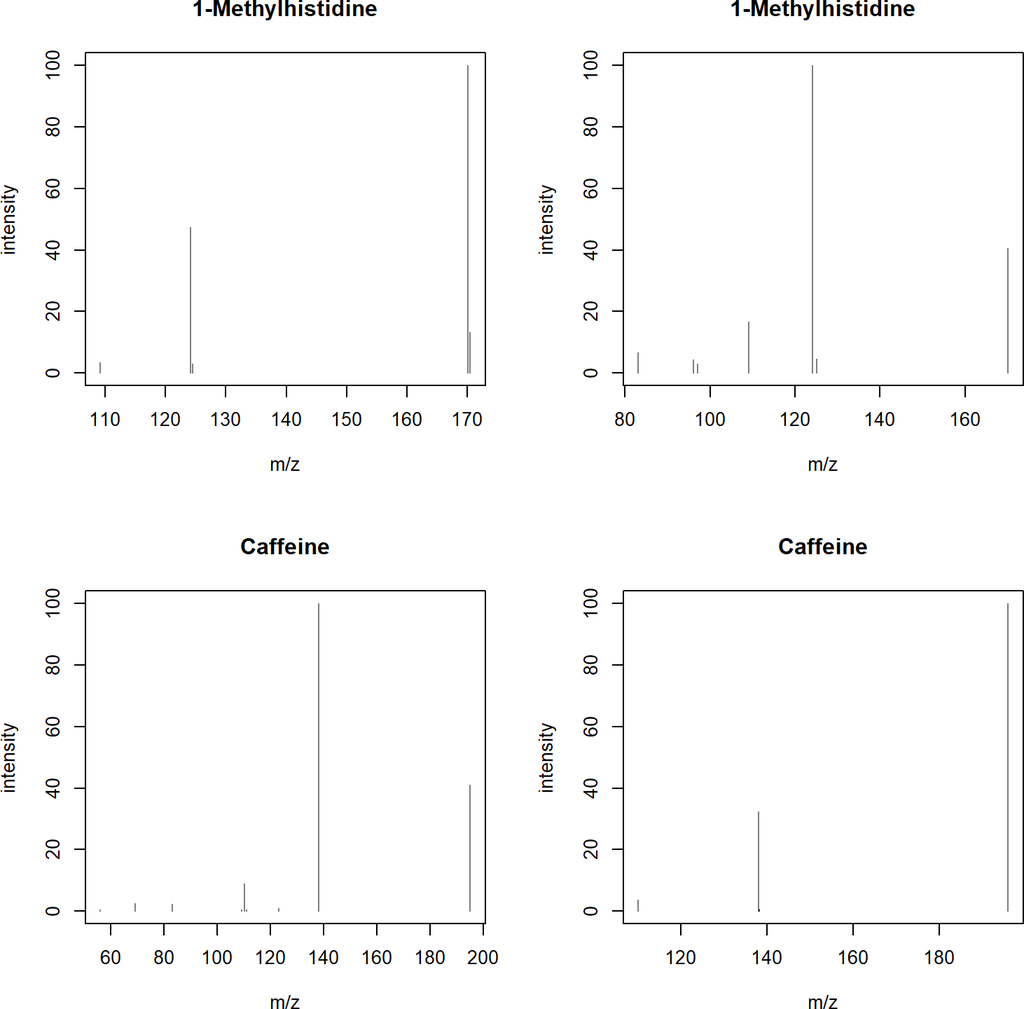

```r
plotSpectra(sps, main = sps$name)
```

It is also possible to label individual peaks in each plot. Below we use the m/z value of each peak as its label. In the example we define a function that accesses information from each spectrum (`z`) and returns a `character` for each peak with the text that should be used as label. Parameters `labelSrt`, `labelPos` and `labelOffset` define the rotation of the label text and its position relative to the x and y coordinates of the peak.

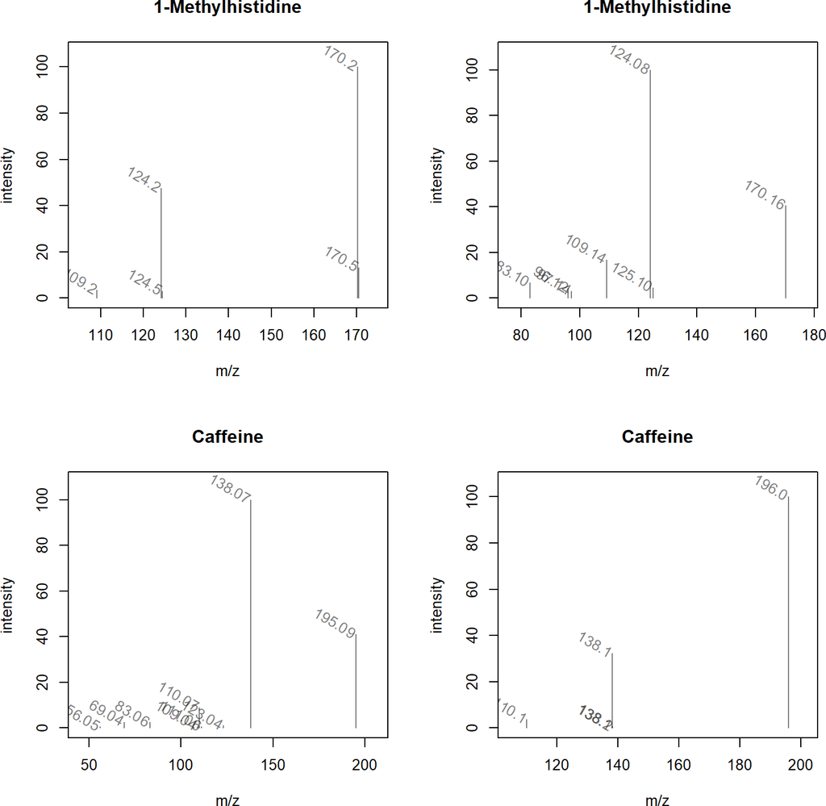

```r
plotSpectra(sps, main = sps$name,
            labels = function(z) format(mz(z)[[1L]], digits = 4),
            labelSrt = -30, labelPos = 2, labelOffset = 0.1)
```

These plots are rather busy and for some peaks the m/z values are overplotted. Below we define a *label function* that will only indicate the m/z of peaks with an intensity higher than 30.

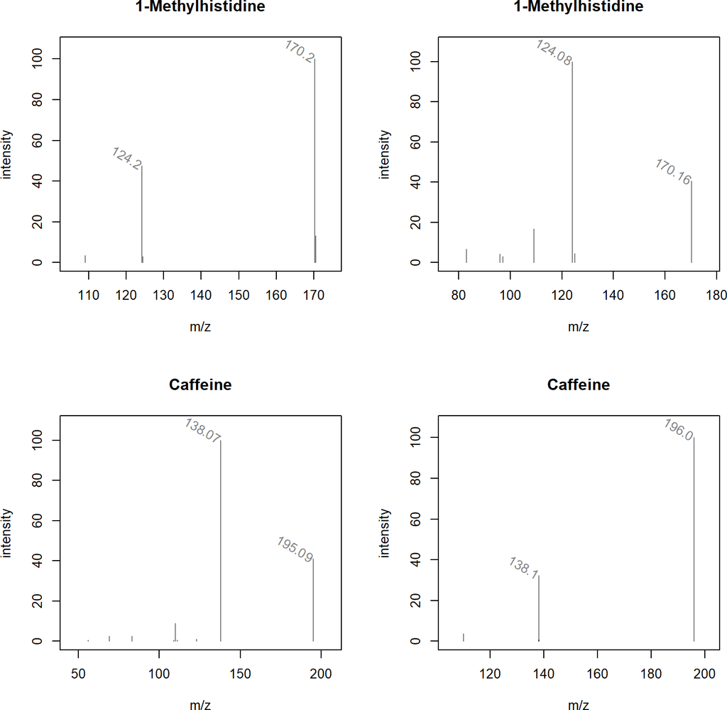

```r
mzLabel <- function(z) {
    z <- peaksData(z)[[1L]]
    lbls <- format(z[, "mz"], digits = 4)
    lbls[z[, "intensity"] < 30] <- ""
    lbls
}
plotSpectra(sps, main = sps$name, labels = mzLabel,
            labelSrt = -30, labelPos = 2, labelOffset = 0.1)
```

Sometimes it might be of interest to plot multiple spectra into the **same** plot (e.g. to directly compare peaks from multiple spectra). This can be done with `plotSpectraOverlay` which we use below to create an *overlay-plot* of our 4 example spectra, using a different color for each spectrum.

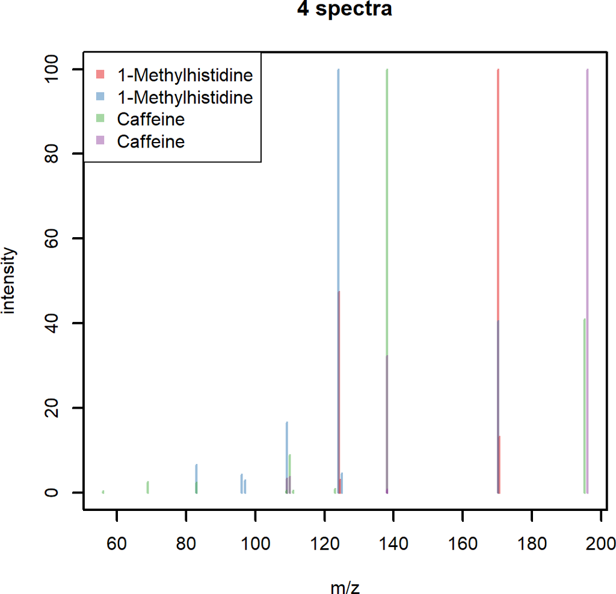

```r
cols <- c("#E41A1C80", "#377EB880", "#4DAF4A80", "#984EA380")
plotSpectraOverlay(sps, lwd = 2, col = cols)
legend("topleft", col = cols, legend = sps$name, pch = 15)
```

Lastly, `plotSpectraMirror` allows to plot two spectra against each other as a *mirror plot* which is ideal to visualize spectra comparison results. Below we plot a spectrum of 1-Methylhistidine against one of Caffeine.

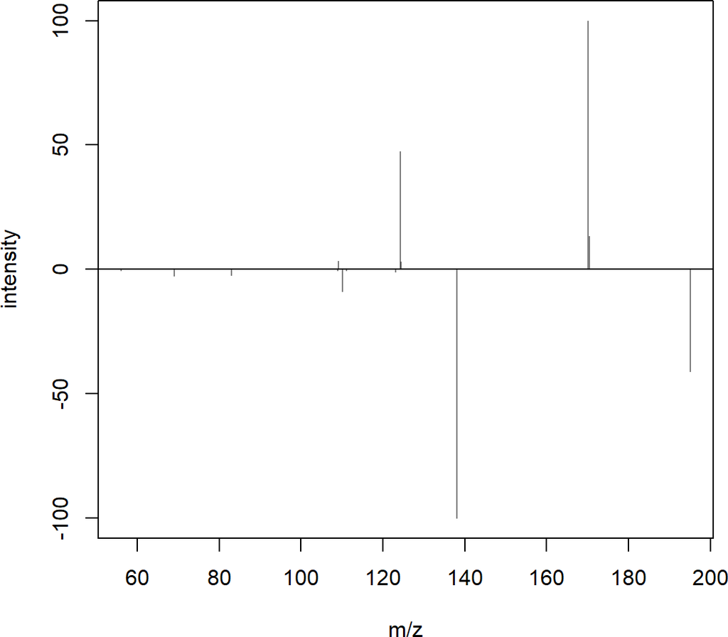

```r
plotSpectraMirror(sps[1], sps[3])
```

The upper panel shows the spectrum from 1-Methylhistidine, the lower the one of Caffeine. None of the peaks of the two spectra match. Below we plot the two spectra of 1-Methylhistidine and the two of Caffeine against each other matching peaks with a `ppm` of 50.

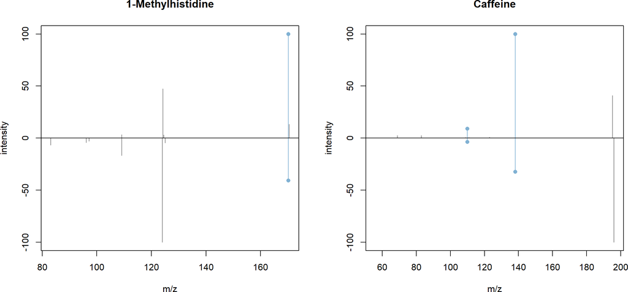

```r
par(mfrow = c(1, 2))
plotSpectraMirror(sps[1], sps[2], main = "1-Methylhistidine", ppm = 50)
plotSpectraMirror(sps[3], sps[4], main = "Caffeine", ppm = 50)
```

See also `?plotSpectra` for more plotting options and examples.

## 3.6 Aggregating spectra data

The `Spectra` package provides the `combineSpectra` function that allows to *aggregate* multiple spectra into a single one. The main parameters of this function are `f`, which defines the grouping of the spectra, and `FUN` which allows to define the function that performs the actual aggregation. The default aggregation function is `combinePeaksData` (see `?combinePeaksData` for details) that combines multiple spectra into a single spectrum with all peaks from all input spectra (with additional paramter `peaks = "union"`), or peaks that are present in a certain proportion of input spectra (with parameter `peaks = "intersect"`; parameter `minProp` allows to define the minimum required proportion of spectra in which a peak needs to be present. Below we use this function to combine the spectra for 1-methylhistidine and caffeine into a single spectrum for each compound. We use the spectra variable `$name`, that contains the names of the compounds, to define which spectra should be grouped together.

```r
sps_agg <- combineSpectra(sps, f = sps$name)
```

As a result, the 4 spectra got aggregated into two.

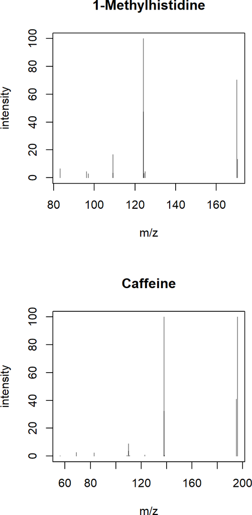

```r
plotSpectra(sps_agg, main = sps_agg$name)
```

By default, all peaks present in all spectra are reported. As an alternative, by specifying `peaks = "intersect"` and `minProp = 1`, we could combine the spectra keeping only peaks that are present in **both** input spectra.

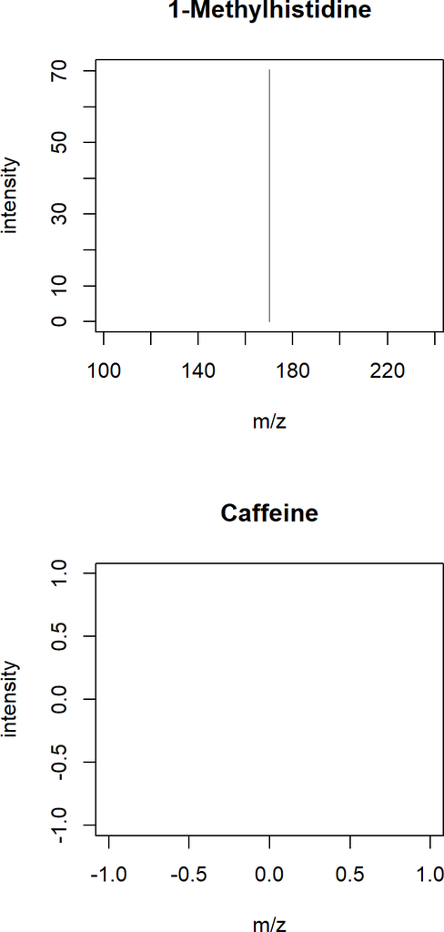

```r
sps_agg <- combineSpectra(sps, f = sps$name, peaks = "intersect", minProp = 1)
plotSpectra(sps_agg, main = sps_agg$name)
```

This results thus in a single peak for 1-methylhistidine and none for caffeine - why? The reason for that is that the difference of the peaks’ m/z values is larger than the default tolerance used for the peak grouping (the defaults for `combinePeaksData` is `tolerance = 0` and `ppm = 0`). We could however already see in the previous section that the reported peaks’ m/z values have a larger measurement error (most likely because the fragment spectra were measured on different instruments with different precision). Thus, we next increase the `tolerance` and `ppm` parameters to group also peaks with a larger difference in their m/z values.

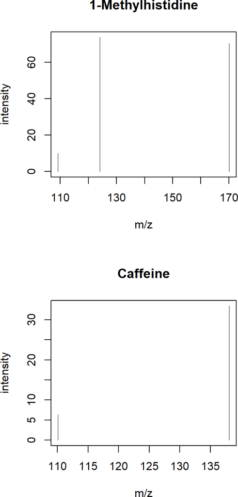

```r
sps_agg <- combineSpectra(sps, f = sps$name, peaks = "intersect",
                          minProp = 1, tolerance = 0.2)
plotSpectra(sps_agg, main = sps_agg$name)
```

Whether in a real analysis we would be OK with such a large tolerance is however questionable. Note: which m/z and intensity is reported for the aggregated spectra can be defined with the parameters `intensityFun` and `mzFun` of `combinePeaksData` (see `?combinePeaksData` for more information).

While the `combinePeaksData` function is indeed helpful to combine peaks from different spectra, the `combineSpectra` function would in addition also allow us to provide our own, custom, peak aggregation function. As a simple example, instead of combining the spectra, we would like to select one of the input spectra as *representative* spectrum for grouped input spectra. `combineSpectra` supports any function that takes a list of peak matrices as input and returns a single peak matrix as output. We thus define below a function that calculates the total signal (TIC) for each input peak matrix, and returns the one peak matrix with the largest TIC.

```r
#' function to select and return the peak matrix with the largest tic from
#' the provided list of peak matrices.
maxTic <- function(x, ...) {
    tic <- vapply(x, function(z) sum(z[, "intensity"], na.rm = TRUE),
                  numeric(1))
    x[[which.max(tic)]]
}
```

We can now use this function with `combineSpectra` to select for each compound the spectrum with the largest TIC.

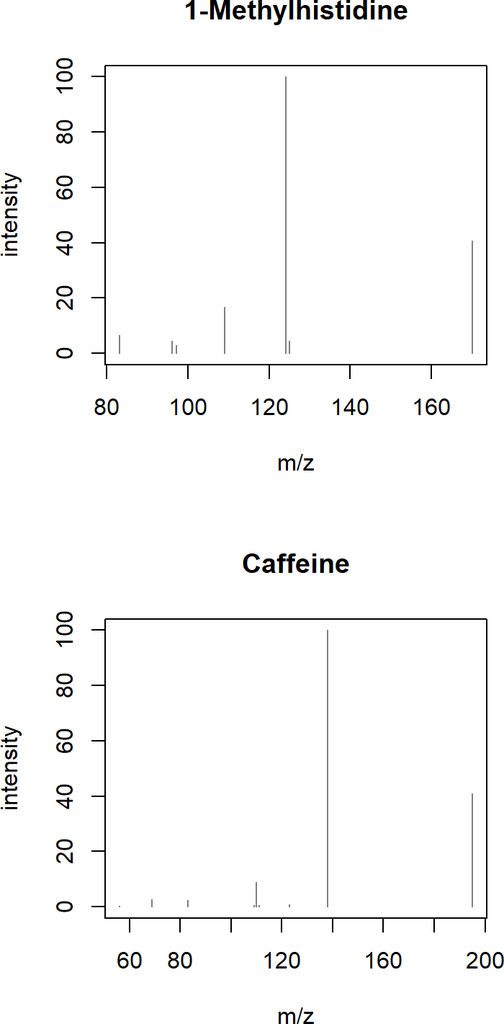

```r
sps_agg <- combineSpectra(sps, f = sps$name, FUN = maxTic)
plotSpectra(sps_agg, main = sps_agg$name)
```

## 3.7 Comparing spectra

Spectra can be compared with the `compareSpectra` function, that allows to calculate similarities between spectra using a variety of methods. `compareSpectra` implements similarity scoring as a two-step approach: first the peaks from the pair of spectra that should be compared are matched (mapped) against each other and then a similarity score is calculated on these. The `MAPFUN` parameter of `compareSpectra` defines the function to match (or map) the peaks between the spectra and parameter `FUN` specifies the function to calculate the similarity. By default, `compareSpectra` uses `MAPFUN = joinPeaks` (see `?joinPeaks` for a description and alternative options) and `FUN = ndotproduct` (the normalized dot-product spectra similarity score). Parameters to configure these functions can be passed to `compareSpectra` as additional parameter (such as e.g. `ppm` to define the m/z-relative tolerance for peak matching in `joinPeaks`).

Below we calculate pairwise similarities between all spectra in `sps` accepting a 50 ppm difference of peaks’ m/z values for being considered matching.

```r
compareSpectra(sps, ppm = 50)
```

```
##           1         2         3         4
## 1 1.0000000 0.1380817 0.0000000 0.0000000
## 2 0.1380817 1.0000000 0.0000000 0.0000000
## 3 0.0000000 0.0000000 1.0000000 0.1817149
## 4 0.0000000 0.0000000 0.1817149 1.0000000
```

The resulting matrix provides the similarity scores from the pairwise comparison. As expected, the first two and the last two spectra are similar, albeit only moderately, while the spectra from 1-Methylhistidine don’t share any similarity with those of Caffeine. Similarities *between* `Spectra` objects can be calculated with calls in the form of `compareSpectra(a, b)` with `a` and `b` being the two `Spectra` objects to compare. As a result a *n x m* matrix will be returned with *n* (rows) being the spectra in `a` and *m* (columns) being the spectra in `b`.

The above similarity was calculated with the default (normalized) dot-product, but also other similarity scores can be used instead. Either one of the other metrics provided by the *MsCoreUtils* could be used (see `?MsCoreUtils::distance` for a list of available options) or any other external or user-provided similarity scoring function. As an example, we use below the spectral entropy similarity score introduced in (Y et al. 2021) and provided with the [*msentropy*](https://cran.r-project.org/web/packages/msentropy/index.html) package. Since this `msentropy_similarity` function performs also the mapping of the peaks between the compared spectra internally (along with some spectra cleaning), we have to disable that in the `compareSpectra` function using `MAPFUN = joinPeaksNone`. To configure the similarity scoring we can pass all additional parameters of the `msentropy_similarity` (see `?msentropy_similarity`) to the `compareSpectra` call. We use `ms2_tolerance_in_ppm = 50` to set the tolerance for m/z-relative peak matching (equivalent to `ppm = 50` used above) and `ms2_tolerance_in_da = -1` to disable absolute tolerance matching.

```r
library(msentropy)
```

```r
compareSpectra(sps, MAPFUN = joinPeaksNone, FUN = msentropy_similarity,
               ms2_tolerance_in_ppm = 50, ms2_tolerance_in_da = -1)
```

```
##           1         2         3         4
## 1 1.0000000 0.3002225 0.0000000 0.0000000
## 2 0.3002225 1.0000000 0.0000000 0.0000000
## 3 0.0000000 0.0000000 1.0000000 0.5144764
## 4 0.0000000 0.0000000 0.5144764 1.0000000
```

Note also that GNPS-like scores can be calculated with `MAPFUN = joinPeaksGnps` and `FUN = MsCoreUtils::gnps`. For additional information and examples see also (Rainer et al. 2022) or the SpectraTutorials tutorial.

Another way of comparing spectra would be to *bin* the spectra and to cluster them based on similar intensity values. Spectra binning ensures that the binned m/z values are comparable across all spectra. Below we bin our spectra using a bin size of 0.1 (i.e. all peaks with an m/z smaller than 0.1 are aggregated into one binned peak.

```r
sps_bin <- Spectra::bin(sps, binSize = 0.1)
```

All spectra will now have the same number of m/z values.

```r
lengths(sps_bin)
```

```
## [1] 1400 1400 1400 1400
```

Most of the intensity values for these will however be 0 (because in the original spectra no peak for the respective m/z bin was present).

```r
intensity(sps_bin)
```

```
## NumericList of length 4
## [[1]] 0 0 0 0 0 0 0 0 0 0 0 0 0 0 0 0 0 0 ... 0 0 0 0 0 0 0 0 0 0 0 0 0 0 0 0 0
## [[2]] 0 0 0 0 0 0 0 0 0 0 0 0 0 0 0 0 0 0 ... 0 0 0 0 0 0 0 0 0 0 0 0 0 0 0 0 0
## [[3]] 0.459 0 0 0 0 0 0 0 0 0 0 0 0 0 0 ... 0 0 0 0 0 40.994 0 0 0 0 0 0 0 0 0
## [[4]] 0 0 0 0 0 0 0 0 0 0 0 0 0 0 0 0 0 ... 0 0 0 0 0 0 0 0 0 0 0 0 0 0 0 0 100
```

We’re next creating an intensity matrix for our `Spectra` object, each row being one spectrum and columns representing the binned m/z values.

```r
intmat <- do.call(rbind, intensity(sps_bin))
```

We can now identify those columns (m/z bins) with only 0s across all spectra and remove these.

```r
zeros <- colSums(intmat) == 0
intmat <- intmat[, !zeros]
intmat
```

```
##       [,1]  [,2]  [,3]  [,4]  [,5]  [,6]  [,7]   [,8]  [,9] [,10] [,11] [,12]
## [1,] 0.000 0.000 0.000 0.000 0.000 0.000 0.000  0.000 3.407 0.000 0.000 0.000
## [2,] 0.000 0.000 0.000 6.685 4.381 3.022 0.000 16.708 0.000 0.000 0.000 0.000
## [3,] 0.459 2.585 2.446 0.000 0.000 0.000 0.508  0.000 0.000 8.968 0.524 0.974
## [4,] 0.000 0.000 0.000 0.000 0.000 0.000 0.000  0.000 0.000 3.837 0.000 0.000
##      [,13]  [,14] [,15] [,16]   [,17] [,18]   [,19] [,20]  [,21] [,22]
## [1,]     0 47.494 3.094 0.000   0.000 0.000 100.000 13.24  0.000     0
## [2,]   100  0.000 0.000 4.565   0.000 0.000  40.643  0.00  0.000     0
## [3,]     0  0.000 0.000 0.000 100.000 0.000   0.000  0.00 40.994     0
## [4,]     0  0.000 0.000 0.000  32.341 1.374   0.000  0.00  0.000   100
```

The associated m/z values for the bins can be extracted with `mz` from the binned `Spectra` object. Below we use these as column names for the intensity matrix.

```r
colnames(intmat) <- mz(sps_bin)[[1L]][!zeros]
```

This intensity matrix could now for example be used to cluster the spectra based on their peak intensities.

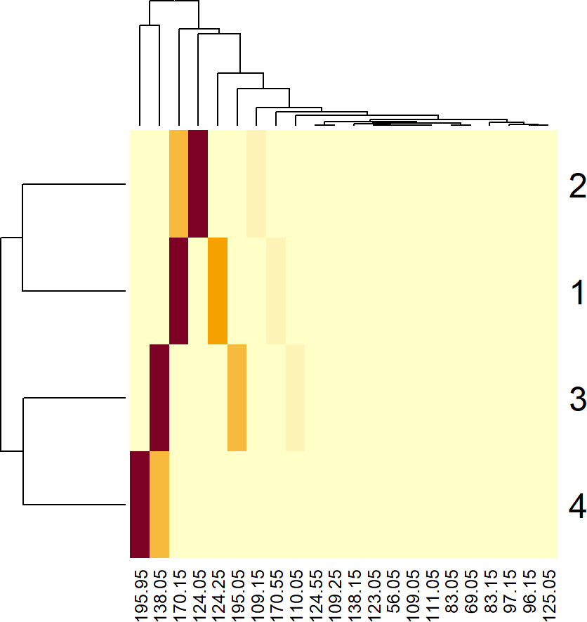

```r
heatmap(intmat)
```

As expected, the first 2 and the last 2 spectra are more similar and are clustered together.

## 3.8 Exporting spectra

Spectra data can be exported with the `export` method. This method takes the `Spectra` that is supposed to be exported and the backend (parameter `backend`) which should be used to export the data and additional parameters for the export function of this backend. The backend thus defines the format of the exported file. Note however that not all `MsBackend` classes might support data export. The backend classes currently supporting data export and its format are: - `MsBackendMzR` (`Spectra` package): export data in *mzML* and *mzXML* format. Can not export all custom, user specified spectra variables. - `MsBackendMgf` ([`MsBackendMgf`](https://RforMassSpectrometry.github.io/MsBackendMgf) package): exports data in *Mascot Generic Format* (mgf). Exports all spectra variables as individual spectrum fields in the mgf file. - `MsBackendMsp` ([`MsBackendMsp`](https://RforMassSpectrometry.github.io/MsBackendMsp)): exports data in NIST MSP format. - `MsBackendMassbank` ([`MsBackendMassbank`](https://RforMassSpectrometry.github.io/MsBackendMassbank)) exports data in Massbank text file format.

In the example below we use the `MsBackendMzR` to export all spectra from the variable `sps` to an mzML file. We thus pass the data, the backend that should be used for the export and the file name of the result file (a temporary file) to the `export` function (see also the help page of the `export,MsBackendMzR` function for additional supported parameters).

```r
fl <- tempfile()
export(sps, MsBackendMzR(), file = fl)
```

```
## Writing file file2b245b177d51...OK
```

To evaluate which of the spectra variables were exported, we load the exported data again and identify spectra variables in the original file which could not be exported (because they are not defined variables in the mzML standard).

```r
sps_im <- Spectra(backendInitialize(MsBackendMzR(), fl))
spectraVariables(sps)[!spectraVariables(sps) %in% spectraVariables(sps_im)]
```

```
## [1] "id"         "name"       "splash"     "instrument"
```

These additional variables were thus not exported. How data export is performed and handled depends also on the used backend. The `MsBackendMzR` for example exports all spectra by default to a single file (specified with the `file` parameter), but it allows also to specify for each individual spectrum in the `Spectra` to which file it should be exported (parameter `file` has thus to be of length equal to the number of spectra). As an example we export below the spectrum 1 and 3 to one file and spectra 2 and 4 to another.

```r
fls <- c(tempfile(), tempfile())
export(sps, MsBackendMzR(), file = fls[c(1, 2, 1, 2)])
```

```
## Writing file file2b2413d84f7...OK
```

```
## Writing file file2b2450b93205...OK
```

A more realistic use case for mzML export would be to export MS data after processing, such as smoothing (using the `smooth` function) and centroiding (using the `pickPeaks` function) of raw profile-mode MS data.

## 3.9 Changing backends

In the previous sections we learned already that a `Spectra` object can use different backends for the actual data handling. It is also possible to change the backend of a `Spectra` to a different one with the `setBackend` function. We could for example change the (`MsBackendMzR`) backend of the `sps_sciex` object to a `MsBackendMemory` backend to enable use of the data even without the need to keep the original mzML files. Below we change the backend of `sps_sciex` to the in-memory `MsBackendMemory` backend.

```r
print(object.size(sps_sciex), units = "Mb")
```

```
## 0.4 Mb
```

```r
sps_sciex <- setBackend(sps_sciex, MsBackendMemory())
sps_sciex
```

```
## MSn data (Spectra) with 1862 spectra in a MsBackendMemory backend:
##        msLevel     rtime scanIndex
##      <integer> <numeric> <integer>
## 1            1     0.280         1
## 2            1     0.559         2
## 3            1     0.838         3
## 4            1     1.117         4
## 5            1     1.396         5
## ...        ...       ...       ...
## 1858         1   258.636       927
## 1859         1   258.915       928
## 1860         1   259.194       929
## 1861         1   259.473       930
## 1862         1   259.752       931
##  ... 33 more variables/columns.
## Processing:
##  Switch backend from MsBackendMzR to MsBackendMemory [Tue Oct 24 23:24:05 2023]
```

With the call the full peak data was imported from the original mzML files into the object. This has obviously an impact on the object’s size, which is now much larger than before.

```r
print(object.size(sps_sciex), units = "Mb")
```

```
## 53.2 Mb
```

The `dataStorage` spectrum variable has now changed, while `dataOrigin` still keeps the information about the originating files:

```r
head(dataStorage(sps_sciex))
```

```
## [1] "<memory>" "<memory>" "<memory>" "<memory>" "<memory>" "<memory>"
```

```r
head(basename(dataOrigin(sps_sciex)))
```

```
## [1] "20171016_POOL_POS_1_105-134.mzML" "20171016_POOL_POS_1_105-134.mzML"
## [3] "20171016_POOL_POS_1_105-134.mzML" "20171016_POOL_POS_1_105-134.mzML"
## [5] "20171016_POOL_POS_1_105-134.mzML" "20171016_POOL_POS_1_105-134.mzML"
```

## 3.10 Parallel processing notes

Most functions on `Spectra` support (and use) parallel processing out of the box. Peak data access and manipulation methods perform by default parallel processing on a per-file basis (i.e. using the `dataStorage` variable as splitting factor). `Spectra` uses *BiocParallel* for parallel processing and all functions use the default registered parallel processing setup of that package (see `?bpparam()` for more information).

Note however that some backends (e.g. those using connections to SQL databases such as `MsBackendMassbank`, `MsBackendSql`) do not support parallel processing because the database connection can not be shared across processes. The `backendBpparam` function allows to evaluate whether a `Spectra` object (or in fact its used `MsBackend` class) supports a certain parallel processing setup. Calling `backendBpparam` on a `Spectra` with a backend that does not support parallel processing would (should) return `SerialParam()`, always. Below we create an empty `Spectra` object and test whether that supports parallel processing.

```r
tmp <- Spectra()
backendBpparam(tmp)
```

```
## class: SnowParam
##   bpisup: FALSE; bpnworkers: 4; bptasks: 0; bpjobname: BPJOB
##   bplog: FALSE; bpthreshold: INFO; bpstopOnError: TRUE
##   bpRNGseed: ; bptimeout: NA; bpprogressbar: FALSE
##   bpexportglobals: TRUE; bpexportvariables: TRUE; bpforceGC: FALSE
##   bpfallback: TRUE
##   bplogdir: NA
##   bpresultdir: NA
##   cluster type: SOCK
```

The backend (in this case a `MsBackendMemory` thus supports parallel processing. We can also specifically test this for individual backends (and parallel setups):

```r
backendBpparam(MsBackendDataFrame(), SnowParam(2))
```

```
## class: SnowParam
##   bpisup: FALSE; bpnworkers: 2; bptasks: 0; bpjobname: BPJOB
##   bplog: FALSE; bpthreshold: INFO; bpstopOnError: TRUE
##   bpRNGseed: ; bptimeout: NA; bpprogressbar: FALSE
##   bpexportglobals: TRUE; bpexportvariables: TRUE; bpforceGC: FALSE
##   bpfallback: TRUE
##   bplogdir: NA
##   bpresultdir: NA
##   cluster type: SOCK
```

# 4 Backends

Backends allow to use different *backends* to store mass spectrometry data while providing *via* the `Spectra` class a unified interface to use that data. This is a further abstraction to the *on-disk* and *in-memory* data modes from `MSnbase` (Gatto, Gibb, and Rainer 2020). The `Spectra` package defines a set of example backends but any object extending the base `MsBackend` class could be used instead. The default backends are:

- `MsBackendMemory`: the *default* backend to store data in memory. Due to its design the `MsBackendMemory` provides fast access to the peaks matrices (using the `peaksData` function) and is also optimized for fast access to spectra variables and subsetting. Since all data is kept in memory, this backend has a relatively large memory footprint (depending on the data) and is thus not suggested for very large MS experiments.
- `MsBackendDataFrame`: the mass spectrometry data is stored (in-memory) in a `DataFrame`. Keeping the data in memory guarantees high performance but has also, depending on the number of mass peaks in each spectrum, a much higher memory footprint.
- `MsBackendMzR`: this backend keeps only general spectra variables in memory and relies on the *mzR* package to read mass peaks (m/z and intensity values) from the original MS files on-demand.
- `MsBackendHdf5Peaks`: similar to `MsBackendMzR` this backend reads peak data only on-demand from disk while all other spectra variables are kept in memory. The peak data are stored in Hdf5 files which guarantees scalability.

All of the above mentioned backends support changing all of their their spectra variables, **except** the `MsBackendMzR` that does not support changing m/z or intensity values for the mass peaks.

With the example below we load the data from a single mzML file and use a `MsBackendHdf5Peaks` backend for data storage. The `hdf5path` parameter allows us to specify the storage location of the HDF5 file.

```r
library(msdata)
fl <- proteomics(full.names = TRUE)[5]

sps_tmt <- Spectra(fl, backend = MsBackendHdf5Peaks(), hdf5path = tempdir())
head(basename(dataStorage(sps_tmt)))
```

```
## [1] "TMT_Erwinia_1uLSike_Top10HCD_isol2_45stepped_60min_01.mzML.h5"
## [2] "TMT_Erwinia_1uLSike_Top10HCD_isol2_45stepped_60min_01.mzML.h5"
## [3] "TMT_Erwinia_1uLSike_Top10HCD_isol2_45stepped_60min_01.mzML.h5"
## [4] "TMT_Erwinia_1uLSike_Top10HCD_isol2_45stepped_60min_01.mzML.h5"
## [5] "TMT_Erwinia_1uLSike_Top10HCD_isol2_45stepped_60min_01.mzML.h5"
## [6] "TMT_Erwinia_1uLSike_Top10HCD_isol2_45stepped_60min_01.mzML.h5"
```

A (possibly incomplete) list of R packages providing additional backends that add support for additional data types or storage options is provided below:

- *MsBackendMgf*: support for import/export of mass spectrometry files in mascot generic format (MGF).
- *MsBackendMsp*: allows to import/export data in NIST MSP format. Extends the `MsBackendDataFrame` and keeps thus all data, after import, in memory.
- `MsBackendMassbank` (package *MsBackendMassbank*): allows to import/export data in MassBank text file format. Extends the `MsBackendDataFrame` and keeps thus all data, after import, in memory.
- `MsBackendMassbankSql` (package *MsBackendMassbank*): allows to directly connect to a MassBank SQL database to retrieve all MS data and variables. Has a minimal memory footprint because all data is retrieved on-the-fly from the SQL database.
- *MsBackendSql*: stores all MS data in a SQL database and has thus a minimal memory footprint.
- `MsBackendCompDb` (package *CompoundDb*): provides access to spectra data (spectra and peaks variables) from a *CompDb* database. Has a small memory footprint because all data (except precursor m/z values) are retrieved on-the-fly from the database.
- *MsBackendRawFileReader*: implements a backend for reading MS data from Thermo Fisher Scientific’s raw data files using the manufacturer’s NewRawFileReader .Net libraries. The package generalizes the functionality introduced by the *rawrr* package, see also (Kockmann and Panse 2021).
- `MsBackendHmdbXml` (package [`MsbackendHmdb`](https://github.com/rformassspectrometry/MsBackendHmdb)): allows import of MS data from xml files of the Human Metabolome Database (HMDB). Extends the `MsBackendDataFrame` and keeps thus all data, after import, in memory.
- `MsBackendTimsTof` (package [`MsBackendTimsTof`](https://github.com/rformassspectrometry/MsBackendTimsTof): allows import of data from Bruker TimsTOF raw data files (using the `opentimsr` R package).
- `MsBackendWeizMass` (package [`MsBackendWeizMass`](https://github.com/rformassspectrometry/MsBackendWeizMass): allows to access MS data from WeizMass MS/MS spectral databases.

# 5 Handling very large data sets

The `Spectra` package was designed to support also efficient processing of very large data sets. Most of the functionality do not require to keep the full MS data in memory (specifically, the peaks data, i.e., m/z and intensity values, which represent the largest chunk of data for MS experiments). For some functions however the peaks data needs to be loaded into memory. One such example is the `lengths` function to determine the number of peaks per spectra that is calculated (on the fly) by evaluating the number of rows of the peaks matrix. Backends such as the `MsBackendMzR` perform by default any data processing separately (and eventually in parallel) by data file and it should thus be safe to call any such functions on a `Spectra` object with that backend. For other backends (such as the [`MsBackendSql`](https://github.com/RforMassSpectrometry/MsBackendSql) or the [`MsBackendMassbankSql`](https://github.com/RforMassSpectrometry/MsBackendMassbank)) it is however advised to process the data in a *chunk-wise* manner using the `spectrapply` function with parameter `chunkSize`. This will split the original `Spectra` object into chunks of size `chunkSize` and applies the function separately to each chunk. That way only data from one chunk will eventually be loaded into memory in each iteration enabling to process also very large `Spectra` objects on computers with limited hardware resources. Instead of a `lengths(sps)` call, the number of peaks per spectra could also be determined (in a less memory demanding way) with `spectrapply(sps, lengths, chunkSize = 5000L)`. In that way only peak data of 5000 spectra at a time will be loaded into memory.

# References

Gatto, Laurent, Sebastian Gibb, and Johannes Rainer. 2020. “MSnbase, Efficient and Elegant R-Based Processing and Visualization of Raw Mass Spectrometry Data.” *Journal of Proteome Research*, September. https://doi.org/10.1021/acs.jproteome.0c00313.

Kockmann, Tobias, and Christian Panse. 2021. “The rawrr R Package: Direct Access to Orbitrap Data and Beyond.” *Journal of Proteome Research*. https://doi.org/10.1021/acs.jproteome.0c00866.

Rainer, Johannes, Andrea Vicini, Liesa Salzer, Jan Stanstrup, Josep M. Badia, Steffen Neumann, Michael A. Stravs, et al. 2022. “A Modular and Expandable Ecosystem for Metabolomics Data Annotation in R.” *Metabolites* 12 (2): 173. https://doi.org/10.3390/metabo12020173.

Y, Li, Kind T, Folz J, Vaniya A, Mehta Ss, and Fiehn O. 2021. “Spectral Entropy Outperforms MS/MS Dot Product Similarity for Small-Molecule Compound Identification.” *Nature Methods* 18 (12). https://doi.org/10.1038/s41592-021-01331-z.